# Alien radio signal

## Background

Imagine we have obtained a USB thumb drive from a top secret project from Area 51 in Nevada.

After hours of decryption and cracking passwords we ended up with a data table with sensor data.

It is not clear what kind of sensor we are talking about.

Your job will be to analyze the file and look for hidden messages in the file.

```r
library(tidyverse)
options(digits = 7) # number of digits printed by R default (vectors, data.frames, lists)
options(pillar.sigfig = 7) # number of digits printed by tibbles default.

df <- read_rds("Assignment\\Assignment 2\\t2.alien_radio_signal.rds")
```

> Q2.1 How many columns do we have in the data?

```r
ncol(df)
```

```
## [1] 4
```

Look at the “group” variable.

> Q2.2 How many groups do we have in the data?

```r
n_distinct(df$group)
```

```
## [1] 3
```

> Q2.3 What is the mean signal strength?

```r
mean(df$signal_strength, na.rm = TRUE)
```

```
## [1] 10.00527
```

> Q2.4 Which of the following statements is true?

Hint: plot the distribution of values for each group

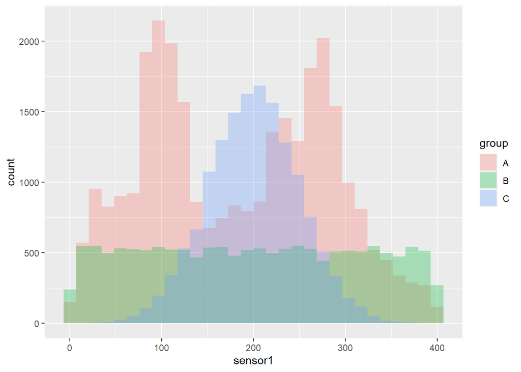

```r
df %>%
    ggplot(aes(x = sensor1, fill = group)) +
    geom_histogram(position = "identity", alpha = 0.3, )
```

1. Sensor 1 show a normal distribution of values in Group A and a uniform (flat) distribution of values in Group B
2. Sensor 1 show a normal distribution of values in Group A and a uniform (flat) distribution of values in Group C
3. Sensor 1 show a normal distribution of values in Group B and a uniform (flat) distribution of values in Group A
4. Sensor 1 show a normal distribution of values in Group B and a uniform (flat) distribution of values in Group C
5. Sensor 1 show a normal distribution of values in Group C and a uniform (flat) distribution of values in Group A
6. Sensor 1 show a normal distribution of values in Group C and a uniform (flat) distribution of values in Group B

The answer should be given as a single number: 1, 2, 3..

6

> Q2.5 What is the mean sensor 2 value in group A?

```r
df %>%
    filter(group == "A") %>%
    select(sensor2) %>%
    colMeans()
```

```
##  sensor2
## 159.7881
```

For the next question, we will focus on group C.

We assume that the sensor1 and sensor2 both are normally distributed and with the same variance.

Our questions is if sensor1 and sensor2 measures the same, i.e. that mean(sensor1)==mean(sensor2)

We want to test this with a simple t.test assuming the same variance/standard variation for the two sensors.

> Q2.6 What is the p value when you do the correct t.test()

One thing is the result of a statistical test. Another question is the effect size.

Now we define the effect size as the absolute (i.e. positive) difference in means.

> Q2.7: What is the absolute difference in means for sensor1 and sensor2 in group C?

Hint: absolute difference = abs(difference)

> Q2.8: What is your conclusion from the two previous questions?
1. We can’t reject H0, so there is no difference between the sensors.
2. It’s not significant, but it’s pretty close, so there could be a difference.
3. It’s significant but the effect size is small.
4. It’s significant and the effect size is huge.
5. It’s extremely significant (p <<< 0.05) but the effect size is small.
6. It’s extremely significant (p <<< 0.05) and the effect size is huge.

The answer should be given as a single number: 1, 2, 3..

Now we will look for patterns in the noise.

1. Identify which group has a bimodal distribution of signal strength.
2. For this group, use the distribution of signal strength to split the data into two smaller sets (one for each peak)
3. Make a scatterplot of the sensor1, sensor2 data columns for each of these data sets

> Q2.9: Which two people are hidden in the data?

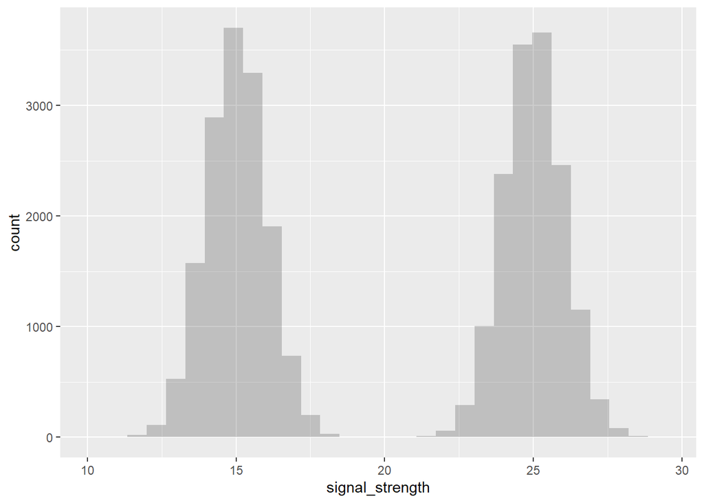

```r
df %>%
    filter(group == "A") %>%
    ggplot(aes(x = signal_strength)) +
    geom_histogram(position = "identity", alpha = 0.3)
```

```r
df <- df %>%
    filter(group == "A") %>%
    mutate(subgroup = ifelse(signal_strength < 20, 1, 2))
```

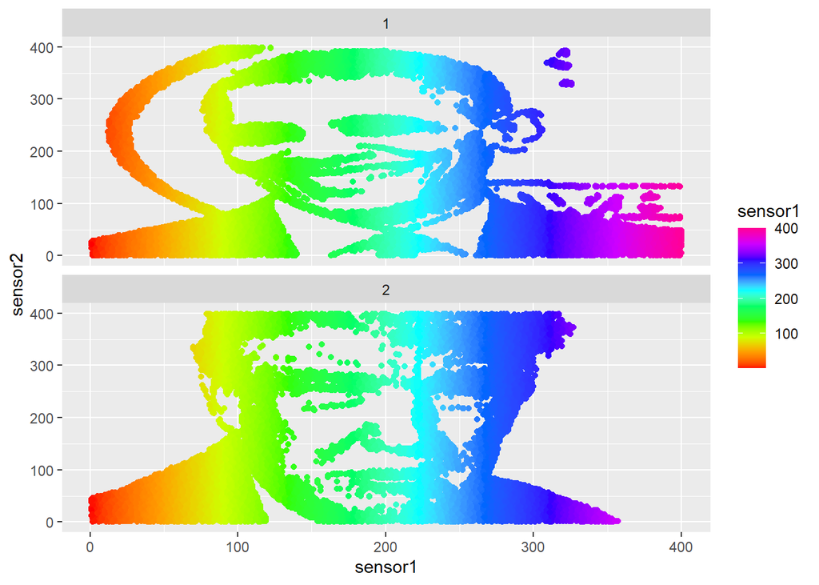

```r
df %>%
    filter(group == "A") %>%
    ggplot(aes(x = sensor1, y = sensor2)) +
    geom_point(aes(color = sensor1)) +
    scale_color_gradientn(colours = rainbow(10)) +
    facet_wrap(~subgroup, ncol = 1)
```

1. Barack Obama & Michelle Obama
2. Barack Obama & Joe Biden
3. Barack Obama & Donald Trump
4. Donald Trump & Melania Trump
5. Donald Trump & Mike Pence
6. Donald Trump & Joe Biden
7. Joe Biden & Jill Biden
8. Joe Biden & Kamala Harris
9. Palle & Thomas

The answer should be given as a single number: 1, 2, 3.. 3